```python
import re
import requests
from bs4 import BeautifulSoup
```

```python
!pip install selenium
```

```python
import re
import requests
import pandas as pd
import numpy as np
import matplotlib.pyplot as plt
import seaborn as sns
from bs4 import BeautifulSoup
from selenium import webdriver
```

```python
path = r"C:\Users\arsha\Downloads\edgedriver_win64\msedgedriver.exe"
```

```python
from selenium.webdriver.edge.service import Service
from selenium.webdriver.edge.options import Options
```

```python
service = Service(executable_path = path)
options = webdriver.EdgeOptions()
```

```python
driver = webdriver.Edge(service=service, options= options)
```

```python
driver.get('https://www.spinny.com/used-cars-in-hyderabad/s/')
```

```python
soup = BeautifulSoup(driver.page_source, "html.parser")
```

```python
soup
```

[output not shown]

```python
Name = []
for i in soup.find_all('div',class_='styles__yearAndMakeAndModelSection'):
    c=i.text
    try :
        regex=re.findall('\s\w+\s(\w.+)',c)
        Name.append(regex[0])
    except:
        Name.append(np.nan)
```

```python
Price=[]
for i in soup.find_all('li',class_='styles__emiWrap'):
    c=i.text
    regex=re.findall('(\d.+)/m',c)
    if regex:
        Price.append(regex[0])
    else:
        Price.append(np.nan)
```

```python
Price
```

```
['12,177',
 '11,103',
 '7,340',
 '9,938',
 '8,760',
 '16,582',
 '29,861',
 '7,463',
 '21,096',
 '7,593',
 '13,305',
 '11,959',
 '15,236',
 '9,501',
 '10,247',
 '16,629',
 '19,986',
 '29,165',
 '18,184',
 '8,464',
 '7,135']
```

```python
soup.find_all('li',class_='styles__toOriginalCase')[6].text
```

```
'60K km'
```

```python
Fuel=[]
for i in soup.find_all('li'):
    c=i.text
    regex=re.findall('petrol|diesel',c)
    if regex:
        Fuel.append(regex[0])

Fuel
```

```
['petrol',
 'diesel',
 'diesel',
 'diesel',
 'petrol',
 'petrol',
 'diesel',
 'petrol',
 'diesel',
 'petrol',
 'diesel',
 'petrol',
 'petrol',
 'petrol',
 'petrol',
 'petrol',
 'petrol',
 'diesel',
 'diesel',
 'petrol',
 'petrol',
 'petrol']
```

```python
links=['hyderabad','chennai','mumbai','bangalore','delhi','delhi-ncr','pune','gurgaon','noida','ahmedabad','kolkata','lucknow','jaipur','kochi','surat','indore','chandigarh','coimbatore','ghaziabad']
Year=[]
Name = []
Model=[]
Price=[]
KM=[]
location=[]
Fuel=[]
MA=[]
EMI=[]

for i in links:
    url=f'https://www.spinny.com/used-cars-in-{i}/s/'
    driver.get(url)
    soup = BeautifulSoup(driver.page_source, "html.parser")
    #location.append(i)

    for i in soup.find_all('div',class_='styles__yearAndMakeAndModelSection'):
        k=i.text
        regex=re.findall('^(\d+)',k)
        if regex:
            Year.append(regex[0])
        else:
            Year.append(np.nan)

    for i in soup.find_all('div',class_='styles__yearAndMakeAndModelSection'):
        c=i.text
        try :
            regex=re.findall('\s(\w+)\s\w+',c)
            Name.append(regex[0])
        except:
            Name.append(np.nan)

    for i in soup.find_all('div',class_='styles__yearAndMakeAndModelSection'):
        c=i.text
        regex=re.findall('\s\w+\s(\w.+)',c)
        if regex:
            Model.append(regex[0])
        else:
            Model.append(np.nan)
    for i in soup.find_all('li',class_='styles__price'):
        c=i.text
        regex=re.findall('(\d.+)Lakh',c)
        if regex:
            Price.append(regex[0])
        else:
            Price.append(np.nan)
    for i in soup.find_all('li',class_='styles__toOriginalCase'):
        c=i.text
        regex=re.findall('(\d.+)K\skm',c)
        if regex:
            KM.append(regex[0])
        else:
            KM.append(np.nan)
    for i in soup.find_all('li'):
        c=i.text
        regex=re.findall('petrol|diesel',c)
        if regex:
            Fuel.append(regex[0])

    for i in soup.find_all('li'):
        c=i.text
        regex=re.findall('manual|automatic',c)
        if regex:
            MA.append(regex[0])

    for i in soup.find_all('li',class_='styles__emiWrap'):
        c=i.text
        regex=re.findall('(\d.+)/m',c)
        if regex:
            EMI.append(regex[0].replace(',',''))
        else:
            EMI.append(np.nan)
    for i in soup.find_all('div',class_='TestDriveAvailability__changeLocationColor'):
        c=i.text
        regex=re.findall('([^ ]+)$',c)
        if regex:
            location.append(regex[0])
        else:
            location.append(np.nan)
```

### Create Pandas Dataframe¶

```python
pd1 = {'Brand':Name, 'Model':Model, 'Year':Year, 'Price(in lakhs)':Price, 'KM(in 1000s)':KM, 'Fuel':Fuel, 'Auto/manual':MA,
       'Location':location, 'EMI':EMI}
```

```python
df=pd.DataFrame.from_dict(pd1,orient='index')
df=df.transpose()
```

```python
df
```

|  | Brand | Model | Year | Price(in lakhs) | KM(in 1000s) | Fuel | Auto/manual | Location | EMI |
| --- | --- | --- | --- | --- | --- | --- | --- | --- | --- |
| 0 | Hyundai | Elite i20 Asta 1.2 | 2016 | 6.69 | 41.0 | petrol | manual | Hyderabad | 12177.0 |
| 1 | Renault | Duster 85 PS RxE ADVENTURE | 2017 | 6.10 | 73.0 | diesel | manual | Hyderabad | 11103.0 |
| 2 | Hyundai | i20 Sportz 1.4 CRDI | 2012 | 3.42 | 95.0 | diesel | manual | Hyderabad | 7340.0 |
| 3 | Ford | EcoSport Titanium 1.5L TDCi | 2014 | 5.46 | 51.0 | diesel | manual | Hyderabad | 9938.0 |
| 4 | Hyundai | i10 Sportz 1.2 Petrol | 2011 | 3.25 | 64.0 | petrol | manual | Hyderabad | 8760.0 |
| ... | ... | ... | ... | ... | ... | ... | ... | ... | ... |
| 413 | BMW | 5 Series 520d Luxury Line | 2020 | 44.90 | 50.0 | diesel | automatic | Gurgaon | 57337.0 |
| 414 | Volvo | XC40 T4 R-Design | 2020 | 35.90 | 36.0 | petrol | automatic | Gurgaon | 20932.0 |
| 415 | Land | Rover Discovery Sport HSE 7-Seater | 2017 | 31.50 | 39.0 | diesel | automatic | Gurgaon | 35494.0 |
| 416 | Jeep | Compass Limited 2.0 Diesel | 2018 | 11.50 | 66.0 | diesel | manual | Gurgaon | NaN |
| 417 | CLA | 200d Urban Edition | 2016 | 19.50 | 22.0 | diesel | automatic | Gurgaon | NaN |

418 rows × 9 columns

### Len of each Column

```python
a = len(Name), len(Model), len(Fuel), len(Year), len(Price), len(KM), len(MA), len(location), len(EMI)
```

```python
a
```

```
(418, 418, 418, 418, 418, 418, 418, 418, 416)
```

### NUll Values

```python
df.isnull().sum()
```

```
Brand               0
Model               0
Year                0
Price(in lakhs)     0
KM(in 1000s)       25
Fuel                0
Auto/manual         0
Location            0
EMI                 2
dtype: int64
```

### filling null values

```python
df['KM(in 1000s)']=df['KM(in 1000s)'].astype('float')
```

```python
df['Price(in lakhs)'].astype('float')
```

```
0       6.69
1       6.10
2       3.42
3       5.46
4       3.25
       ...
413    44.90
414    35.90
415    31.50
416    11.50
417    19.50
Name: Price(in lakhs), Length: 418, dtype: float64
```

```python
df['KM(in 1000s)'].isnull().sum()
```

```
25
```

```python
df.info()
```

```
<class 'pandas.core.frame.DataFrame'>
RangeIndex: 418 entries, 0 to 417
Data columns (total 9 columns):
 #   Column           Non-Null Count  Dtype
---  ------           --------------  -----
 0   Brand            418 non-null    object
 1   Model            418 non-null    object
 2   Year             418 non-null    object
 3   Price(in lakhs)  418 non-null    object
 4   KM(in 1000s)     393 non-null    float64
 5   Fuel             418 non-null    object
 6   Auto/manual      418 non-null    object
 7   Location         418 non-null    object
 8   EMI              416 non-null    object
dtypes: float64(1), object(8)
memory usage: 29.5+ KB
```

```python
df['KM(in 1000s)'].interpolate(how='Price',inplace=True,axis = 0)
```

```python
df.dropna(inplace=True)
```

### Data to CSV

```python
df.to_csv('spinnycars.csv',index=False)
```

```python
dff = pd.read_csv("spinnycars.csv")

dff
```

|  | Brand | Model | Year | Price(in lakhs) | KM(in 1000s) | Fuel | Auto/manual | Location | EMI |
| --- | --- | --- | --- | --- | --- | --- | --- | --- | --- |
| 0 | Hyundai | Elite i20 Asta 1.2 | 2016 | 6.69 | 41.0 | petrol | manual | Hyderabad | 12177.0 |
| 1 | Renault | Duster 85 PS RxE ADVENTURE | 2017 | 6.10 | 73.0 | diesel | manual | Hyderabad | 11103.0 |
| 2 | Hyundai | i20 Sportz 1.4 CRDI | 2012 | 3.42 | 95.0 | diesel | manual | Hyderabad | 7340.0 |
| 3 | Ford | EcoSport Titanium 1.5L TDCi | 2014 | 5.46 | 51.0 | diesel | manual | Hyderabad | 9938.0 |
| 4 | Hyundai | i10 Sportz 1.2 Petrol | 2011 | 3.25 | 64.0 | petrol | manual | Hyderabad | 8760.0 |
| ... | ... | ... | ... | ... | ... | ... | ... | ... | ... |
| 411 | Land | Rover Discovery Sport HSE | 2017 | 30.50 | 50.0 | diesel | automatic | Gurgaon | 81729.0 |
| 412 | BMW | X3 xDrive 20d Luxury Line | 2019 | 44.90 | 59.0 | diesel | automatic | Gurgaon | 65346.0 |
| 413 | BMW | 5 Series 520d Luxury Line | 2020 | 44.90 | 50.0 | diesel | automatic | Gurgaon | 57337.0 |
| 414 | Volvo | XC40 T4 R-Design | 2020 | 35.90 | 36.0 | petrol | automatic | Gurgaon | 20932.0 |
| 415 | Land | Rover Discovery Sport HSE 7-Seater | 2017 | 31.50 | 39.0 | diesel | automatic | Gurgaon | 35494.0 |

416 rows × 9 columns

```python
dff.isnull().sum()
```

```
Brand              0
Model              0
Year               0
Price(in lakhs)    0
KM(in 1000s)       0
Fuel               0
Auto/manual        0
Location           0
EMI                0
dtype: int64
```

```python
dff.dropna(inplace=True)
```

### Statistical analysis and Visualization

### Univairate Plots

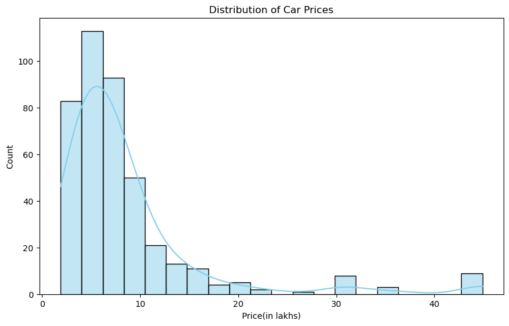

```python
# Histogram of Car Prices using Seaborn
dff = pd.read_csv('spinnycars.csv')
plt.figure(figsize=(10, 6))
sns.histplot(dff['Price(in lakhs)'], bins=20, kde=True, color='skyblue')
plt.title('Distribution of Car Prices')
plt.show()
```

`Interpretation`

- The histogram appears to be right-skewed, indicating that a majority of cars have lower prices, while fewer cars have higher prices. This suggests that most cars in the dataset fall within a relatively affordable price range.
- The peak of the histogram, also known as the mode, provides insight into the most common price range. It helps identify where the majority of cars are priced.
- The long right tail of the histogram suggests the presence of some cars with higher prices than the majority. These may be considered as outliers and could represent luxury or high-performance vehicles.

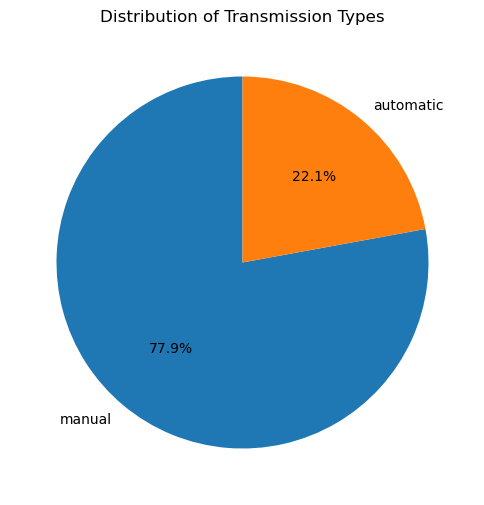

```python
# Pie Chart of Transmission Type Distribution
plt.figure(figsize=(6, 7))
transmission_counts = dff['Auto/manual'].value_counts()
plt.pie(transmission_counts, labels=transmission_counts.index, autopct='%1.1f%%', startangle=90)
plt.title('Distribution of Transmission Types')
plt.show()
```

`Interpretation`

- The pie chart shows the proportion of cars with 'Auto' and 'Manual' transmissions.
- Each slice represents a transmission type, and the size of the slice corresponds to the percentage of cars with that transmission type.

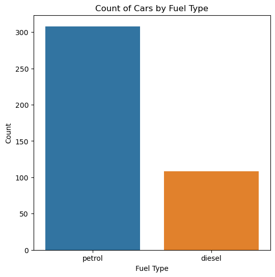

```python
# Bar Plot of Fuel Type Counts
plt.figure(figsize=(6, 6))
sns.countplot(x='Fuel', data=dff)
plt.title('Count of Cars by Fuel Type')
plt.xlabel('Fuel Type')
plt.ylabel('Count')
plt.show()
```

`Interpretation`:

- The count plot visualizes the distribution of cars based on their fuel types.
- Each bar represents a different fuel type, and the height of the bar corresponds to the count or frequency of cars with that specific fuel type. Taller bars indicate a higher prevalence of certain fuel types in the dataset.

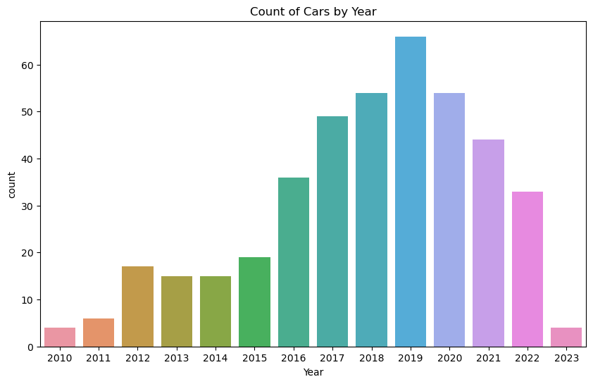

```python
# Count Plot of Car Years
plt.figure(figsize=(10, 6))
sns.countplot(x='Year', data=dff)
plt.title('Count of Cars by Year')
plt.show()
```

`Interpretation`

- The count plot visualizes the number of cars available for each year.
- The height of each bar represents the count of cars from a specific manufacturing year.

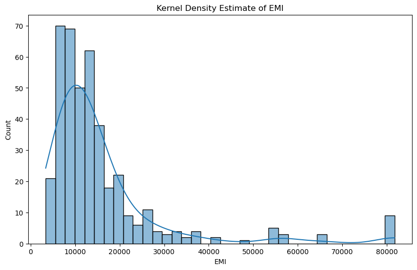

```python
# KDE Plot of Car Prices
plt.figure(figsize=(10, 6))
sns.histplot(dff['EMI'], fill=True,kde=True)
plt.title('Kernel Density Estimate of EMI')

plt.show()
```

`Interpretation`

- The KDE plot shows the estimated probability density of different EMI values. Higher peaks in the plot indicate regions where EMI values are more concentrated.
- The central peak or mode represents the most common range of EMI values. Multiple peaks might indicate the presence of different clusters or patterns in the EMI distribution.
- The width of the KDE plot at different points indicates the variability in EMI values. A wider spread suggests a more diverse range of EMI values.

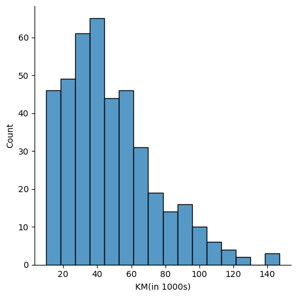

```python
sns.displot(dff, x ='KM(in 1000s)' )
```

`Interpretation`

- The histogram displays the distribution of kilometers (in thousands) traveled by the cars in the dataset.
- The x-axis represents the kilometer values, and the y-axis represents the frequency or count of cars within each kilometer range.
- Peaks in the histogram indicate common ranges of kilometers traveled. Higher bars suggest that more cars fall within those specific kilometer ranges.
- Unusually tall bars or isolated bars far from the main distribution might indicate potential outliers.

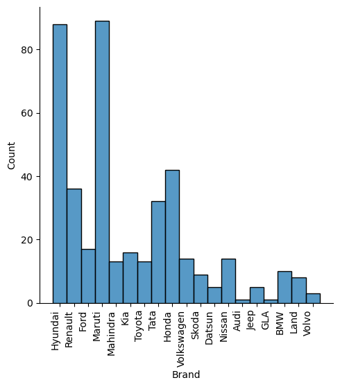

```python
sns.displot(dff['Brand'])
plt.xticks(rotation=90, ha='right')
plt.show()
```

`Interpretation`

- The histogram shows the distribution of cars among different brands.
- Each bar represents a unique brand, and the height of the bar corresponds to the count or frequency of cars belonging to that brand.
- Brands with taller bars indicate that there more common or popular car brands.
- If there are unusually tall it might indicate outlier brands.

### Bivariate Plots

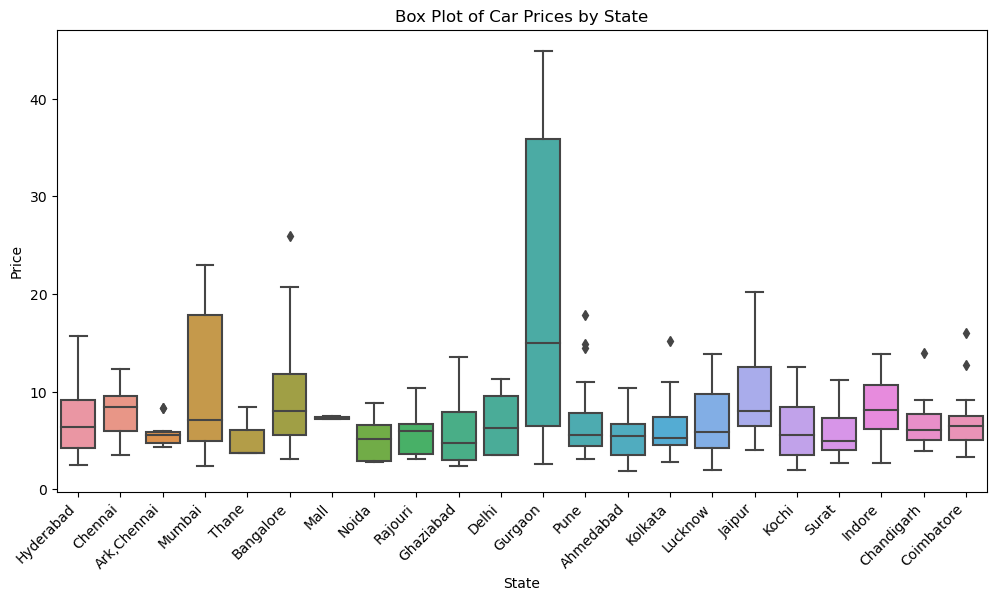

```python
# Boxplot
plt.figure(figsize=(12, 6))
sns.boxplot(x='Location', y='Price(in lakhs)', data=dff)
plt.title('Box Plot of Car Prices by State')
plt.xlabel('State')
plt.ylabel('Price')
plt.xticks(rotation=45, ha='right')
plt.show()
```

`Interpretation`

- The box plot represents the distribution of car prices for different states.
- Each box corresponds to a different state, and the height of the box indicates the interquartile range (IQR) of prices within that state.
- The horizontal line inside each box represents the median price for cars in that state.
- The length of the box (IQR) indicate the variability in car prices within each state.
- Individual points beyond the whiskers represent potential outliers

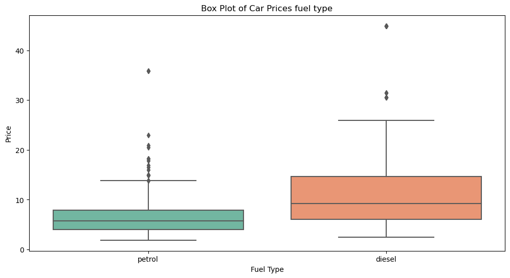

```python
# Box Plot of Car Prices by Fuel Type
plt.figure(figsize=(12, 6))
sns.boxplot(x='Fuel', y='Price(in lakhs)', data=dff, palette='Set2')
plt.title('Box Plot of Car Prices fuel type')
plt.xlabel('Fuel Type')
plt.ylabel('Price')
plt.show()
```

`Interpretation`

- The box plot visually represents the distribution of car prices for different fuel types.
- Each box corresponds to a different fuel type, and the height of the box indicates the interquartile range (IQR) of prices within that fuel type.
- The horizontal line inside each box represents the median price for cars of that fuel type.
- It provides a measure of central tendency, showing the typical price level for each fuel type.
- Individual points beyond the whiskers represent potential outliers

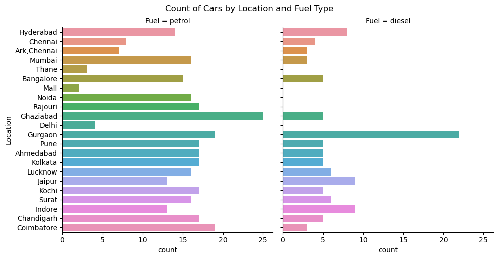

```python
sns.catplot(dff,col='Fuel',y='Location',kind='count')
plt.suptitle('Count of Cars by Location and Fuel Type', y=1.02)
plt.show()
```

`Interpretation`

- The categorical plot displays the count of cars in different locations based on their fuel types.
- Each subplot represents a different fuel type, and the y-axis shows the count of cars in different locations.
- By comparing the subplots, we can observe how the distribution of cars in different locations varies for each fuel type.

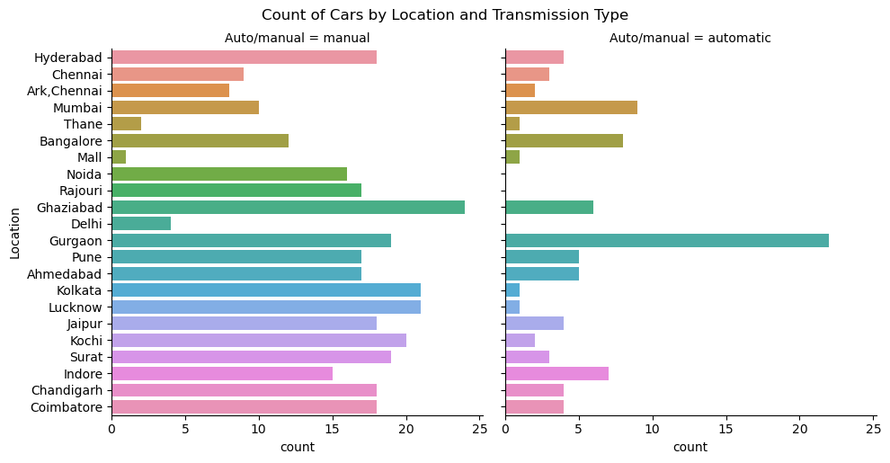

```python
sns.catplot(dff,col='Auto/manual',y='Location',kind='count')
plt.suptitle('Count of Cars by Location and Transmission Type', y=1.02)
plt.show()
```

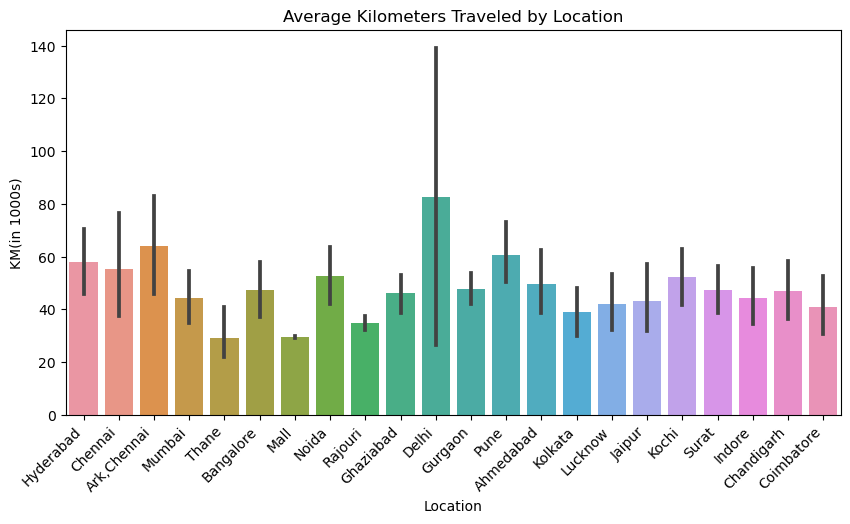

```python
plt.figure(figsize=(10,5))
sns.barplot(dff,y='KM(in 1000s)',x='Location')
plt.title('Average Kilometers Traveled by Location')
plt.xticks(rotation=45, ha='right')
plt.show()
```

`Interpretation`

- The bar plot displays the average kilometers traveled by cars in different locations.
- Each bar represents a different location, and the height of the bar corresponds to the average kilometers traveled in that location.
- By comparing the heights of the bars, you can observe how the average kilometers traveled varies between different locations.

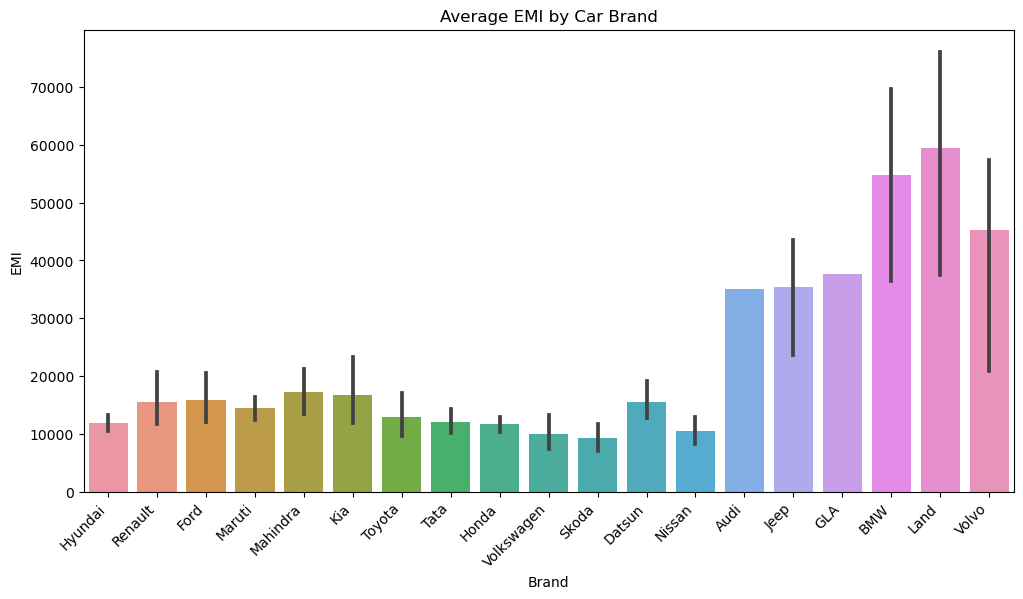

```python
plt.figure(figsize=(12, 6))
sns.barplot(dff,x='Brand',y=dff['EMI'])
plt.title('Average EMI by Car Brand')
plt.xticks(rotation=45, ha='right')
plt.show()
```

`Interpretation`

- The bar plot displays the average Equated Monthly Installment (EMI) for cars of different brands.
- Each bar represents a different car brand, and the height of the bar corresponds to the average EMI for that brand.
- By comparing the heights of the bars, we can observe how the average EMI varies between different car brands.

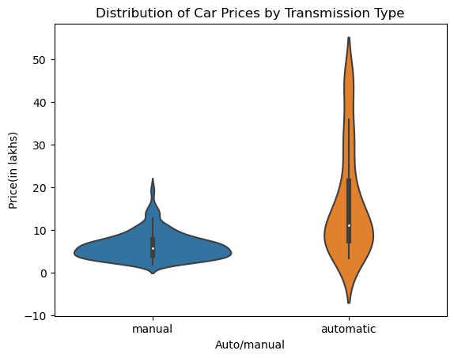

```python
sns.violinplot(dff,x='Auto/manual',y='Price(in lakhs)')
plt.title('Distribution of Car Prices by Transmission Type')
plt.show()
```

`Interpretation`

- The violin plot displays the distribution of car prices for different transmission types ('Auto/manual').
- Each violin shape corresponds to a different transmission type, and the width of the shape indicates the density of prices.
- The horizontal line inside each violin represents the median price for cars of that transmission type.
- Wider sections indicate more cars in that price range. Narrow sections may indicate fewer cars in that specific price range.
- By comparing the widths and shapes of the violins, we can assess how the distribution of prices varies between different transmission types.

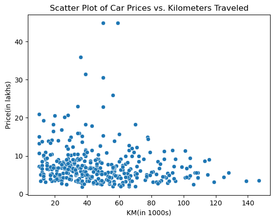

```python
sns.scatterplot(x='KM(in 1000s)', y='Price(in lakhs)', data=dff)
plt.title('Scatter Plot of Car Prices vs. Kilometers Traveled')
plt.show()
```

`Interpretation`

- The scatter plot visualizes the relationship between the kilometers traveled by cars and their prices.
- Each point on the plot represents an individual car, with its position determined by the kilometers traveled (x-axis) and the price (y-axis).
- By observing the general trend of the points, you can identify whether there is a correlation between kilometers traveled and prices.
- For example, a negative correlation might suggest that cars with more kilometers tend to have lower prices.

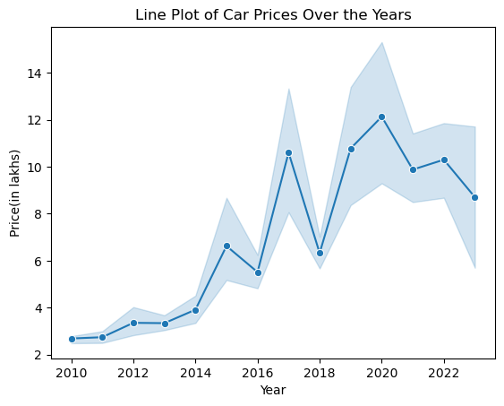

```python
sns.lineplot(x='Year', y='Price(in lakhs)', data=dff, marker='o')
plt.title('Line Plot of Car Prices Over the Years')
plt.show()
```

`Interpretation`

- The line plot visualizes how car prices change over different years.
- Each point on the line represents the average price of cars in a specific year.
- By observing the trend of the line, you can identify whether there is an overall increase, decrease, or stability in car prices over the years.
- Fluctuations in the line indicate variations in car prices from year to year.

### Multivariate Plots

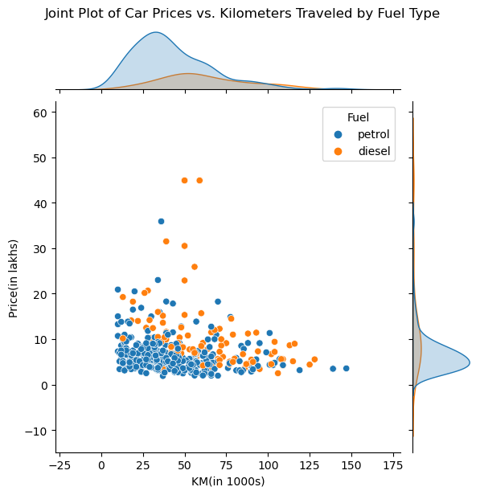

```python
sns.jointplot(x='KM(in 1000s)', y='Price(in lakhs)',hue='Fuel', data=dff)
plt.suptitle('Joint Plot of Car Prices vs. Kilometers Traveled by Fuel Type', y=1.02)
plt.show()
```

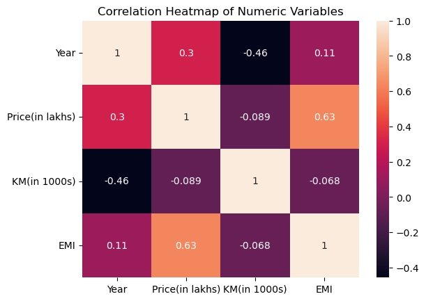

```python
df2=dff.select_dtypes(include='number')
sns.heatmap(df2.corr(),annot=True)
plt.title('Correlation Heatmap of Numeric Variables')
plt.show()
```

`Interpretation`

- The heatmap visually represents the correlation between numeric variables in the dataset.
- Each cell in the heatmap corresponds to the correlation coefficient between two variables.
- The color scale indicates the strength and direction of the correlation. Positive correlations are typically shown in warmer colors (e.g., red), while negative correlations are in cooler colors (e.g., black).
- High positive values suggest a strong positive correlation, meaning the variables move together.
- High negative values indicate a strong negative correlation, suggesting an inverse relationship.
- Values close to zero suggest a weak or no correlation.

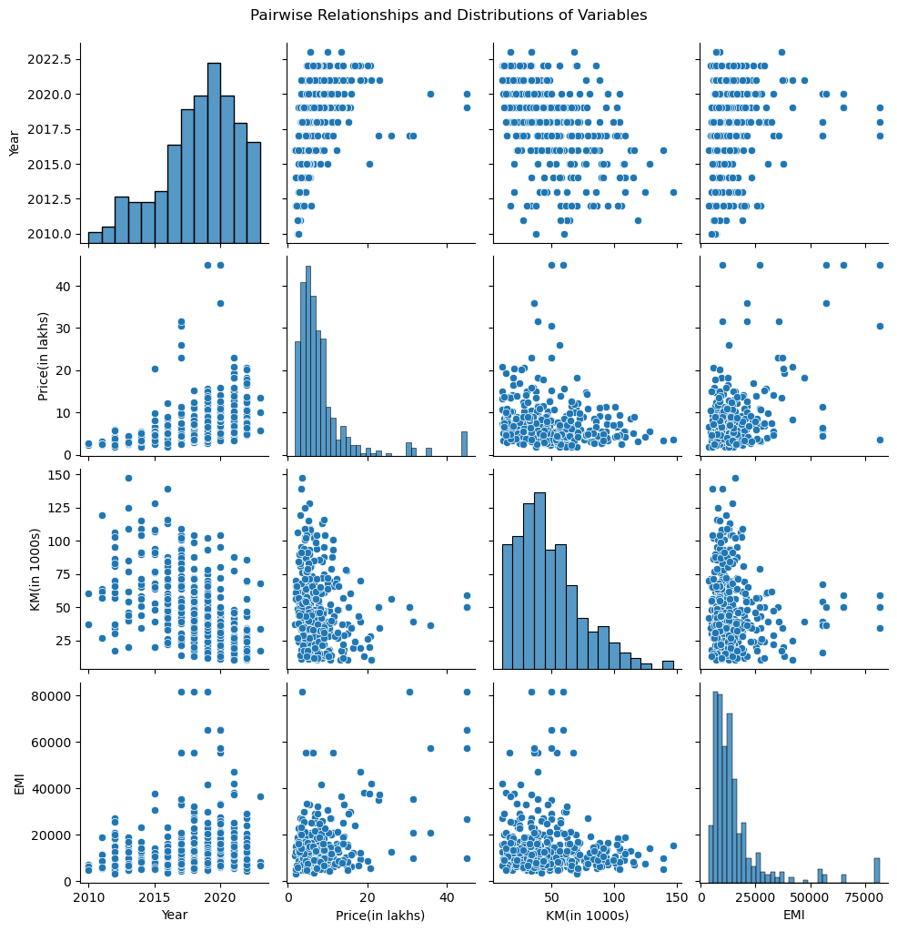

```python
sns.pairplot(dff)
plt.suptitle('Pairwise Relationships and Distributions of Variables', y=1.02)
plt.show()
```

`Interpretation`

- The pair plot provides a comprehensive view of the relationships and distributions between all numeric variables in the dataset.
- Each off-diagonal subplot is a scatterplot showing the relationship between two variables. Help to identify trends and patterns
- The diagonal subplots show histograms of individual variables, giving insights into their distributions. it also reveal the shape of the distribution for each variable.

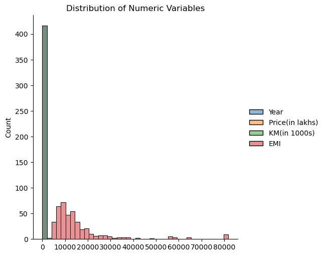

```python
sns.displot(df2,bins=40)
plt.title('Distribution of Numeric Variables')
plt.show()
```

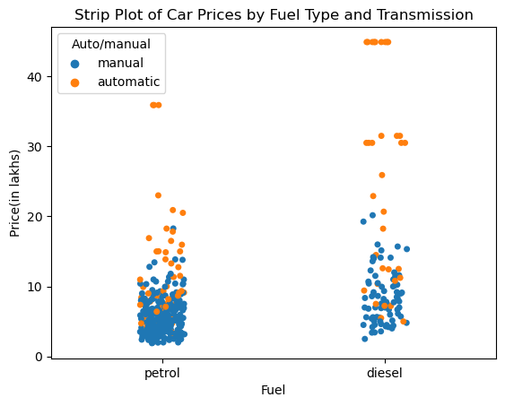

```python
sns.stripplot(dff,y='Price(in lakhs)',x='Fuel',hue='Auto/manual')
plt.title('Strip Plot of Car Prices by Fuel Type and Transmission')
plt.show()
```

### Checking outliers

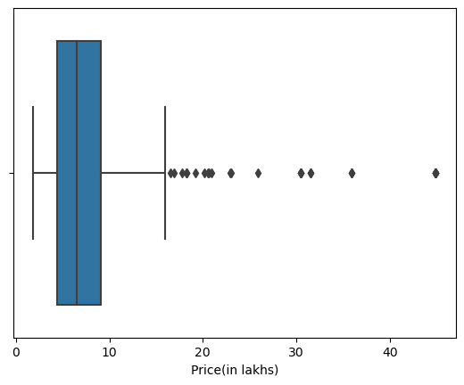

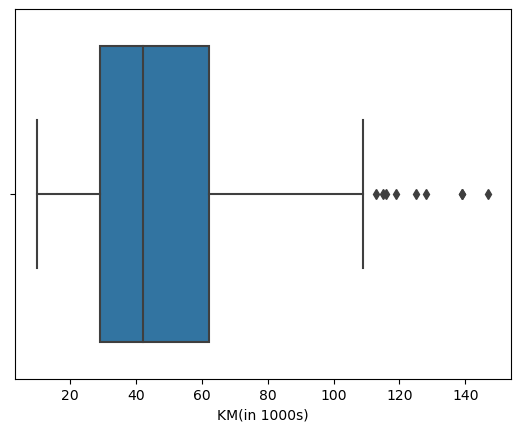

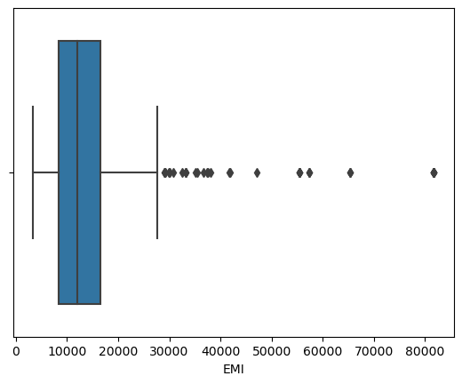

```python
for col in dff. columns:
    if dff[col].dtype=='float64':
        sns.boxplot(dff,x=col,)
    plt.show()
```

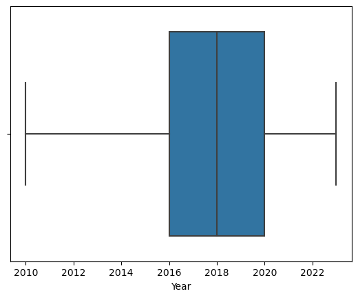

```python
for col in dff. columns:
    if dff[col].dtype=='int64':
        sns.boxplot(dff,x=col,)
    plt.show()
```

### Business porblem analysis

#### Client-1

> A person wants a car which has travelled less than 50 thousand Kilometers?

#### Client-2

> A person wants to buy a second hand car with in a budget of 5 lakhs.suggest cars whose prices are under 5 lakhs

#### Client-3

> A person wants to buy a manual diesel car and wants to know the minimum amount of budget he should have

#### Client-4

> a person wants to know which brands offer manual cars.

#### Client-5

> a person wants to buy a car whose emi is under 9000

```python
dff
```

|  | Brand | Model | Year | Price(in lakhs) | KM(in 1000s) | Fuel | Auto/manual | Location | EMI |
| --- | --- | --- | --- | --- | --- | --- | --- | --- | --- |
| 0 | Hyundai | Elite i20 Asta 1.2 | 2016 | 6.69 | 41.0 | petrol | manual | Hyderabad | 12177.0 |
| 1 | Renault | Duster 85 PS RxE ADVENTURE | 2017 | 6.10 | 73.0 | diesel | manual | Hyderabad | 11103.0 |
| 2 | Hyundai | i20 Sportz 1.4 CRDI | 2012 | 3.42 | 95.0 | diesel | manual | Hyderabad | 7340.0 |
| 3 | Ford | EcoSport Titanium 1.5L TDCi | 2014 | 5.46 | 51.0 | diesel | manual | Hyderabad | 9938.0 |
| 4 | Hyundai | i10 Sportz 1.2 Petrol | 2011 | 3.25 | 64.0 | petrol | manual | Hyderabad | 8760.0 |
| ... | ... | ... | ... | ... | ... | ... | ... | ... | ... |
| 411 | Land | Rover Discovery Sport HSE | 2017 | 30.50 | 50.0 | diesel | automatic | Gurgaon | 81729.0 |
| 412 | BMW | X3 xDrive 20d Luxury Line | 2019 | 44.90 | 59.0 | diesel | automatic | Gurgaon | 65346.0 |
| 413 | BMW | 5 Series 520d Luxury Line | 2020 | 44.90 | 50.0 | diesel | automatic | Gurgaon | 57337.0 |
| 414 | Volvo | XC40 T4 R-Design | 2020 | 35.90 | 36.0 | petrol | automatic | Gurgaon | 20932.0 |
| 415 | Land | Rover Discovery Sport HSE 7-Seater | 2017 | 31.50 | 39.0 | diesel | automatic | Gurgaon | 35494.0 |

416 rows × 9 columns

### Client-1

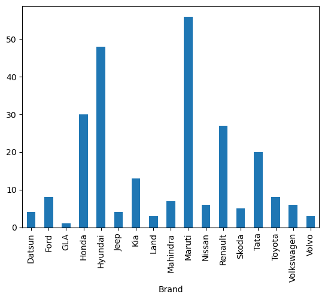

```python
cd = dff[dff['KM(in 1000s)'] < 50]
cd.groupby('Brand')['KM(in 1000s)'].count().plot.bar()
```

### Client-2

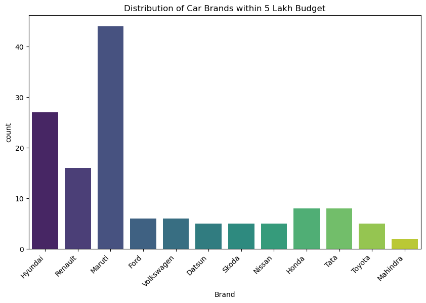

```python
dvd = dff[dff['Price(in lakhs)'] <= 5]
plt.figure(figsize=(10, 6))
sns.countplot(x='Brand', data=dvd, palette='viridis')
plt.title('Distribution of Car Brands within 5 Lakh Budget')
plt.xticks(rotation=45, ha='right')
plt.show()
```

### Client-3

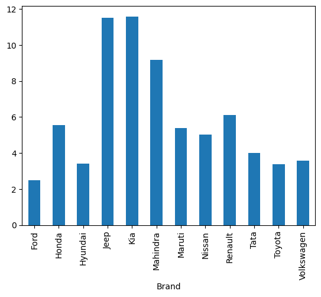

```python
md = dff[dff['Auto/manual'] =='manual']
m =md[md['Fuel'] =='diesel']
m.groupby('Brand')['Price(in lakhs)'].min().plot.bar()
```

### client4

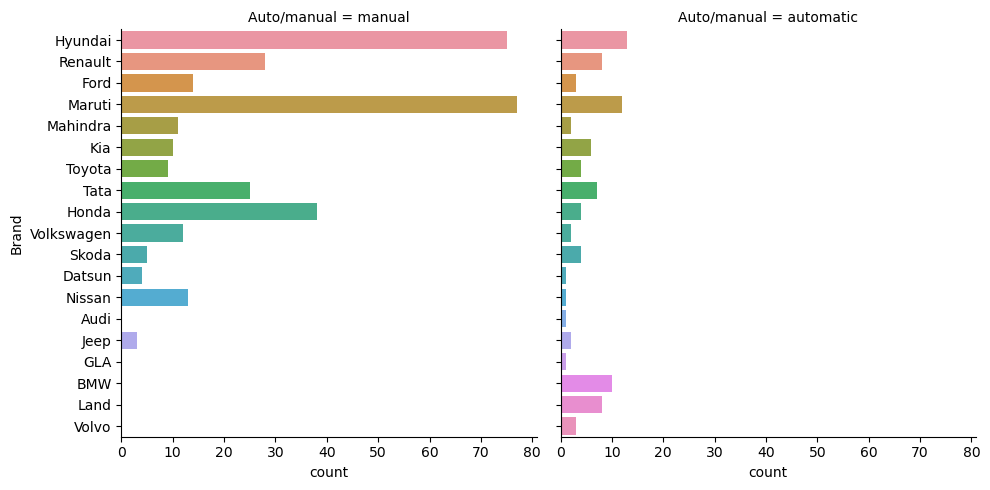

```python
sns.catplot(dff,col='Auto/manual',y='Brand',kind='count')
```

### client 5

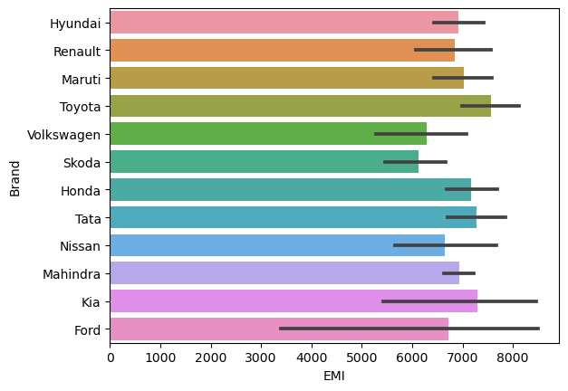

```python
dvd = dff[dff['EMI'] <= 9000]
sns.barplot(dvd,y='Brand',x=dvd['EMI'])
```

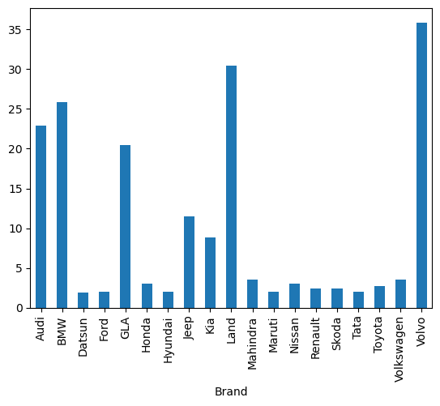

```python
dff.groupby('Brand')['Price(in lakhs)'].min().plot.bar()
```